# Predicting Hotel Booking Cancellations: A Statistical and Machine Learning Approach

Nnenna Ifeanyi, Mohita Talasila, Akshitha Pathuru, Venkata Sai Rakesh Tiruvuru

2025-02-28

# Introduction

The hotel industry plays a crucial role in the global economy, yet it continuously faces challenges related to fluctuating demand and high cancellation rates. Understanding the key drivers of booking trends and cancellations is essential for optimizing revenue management, improving customer satisfaction, and enhancing operational efficiency. This study aims to analyze the critical factors influencing hotel booking cancellations, including:

- **Seasonality & Weather Fluctuations** – Peak seasons boost bookings, while adverse weather leads to higher cancellations.
- **Pricing Strategies & Discounts** – Competitive pricing, early-bird offers, and dynamic rates influence booking commitment.
- **Booking Platforms & Policies** – Online travel agencies (OTAs) provide flexible cancellations, whereas direct hotel bookings enforce stricter rules.
- **Customer Segmentation** – Business traveler’s book with certainty, while leisure travelers show more cancellation tendencies.
- **Economic Shifts & Market Trends** – Recessions, inflation, and exchange rates impact global and local travel demand.
- **Hotel Reputation & Digital Presence** – Online reviews and brand loyalty strongly dictate customer trust and booking rates.
- **Unpredictable Disruptions** – Pandemics, natural disasters, and strikes trigger large-scale cancellations.
- **Cancellation Policies & Refund Options** – Non-refundable rates lower cancellations but deter risk-averse travelers.
- **AI & Smart Booking Technologies** – Machine learning-based pricing and chatbot engagement shape modern booking behaviors.

By examining these factors, this study seeks to provide data-driven insights that can help hotels refine pricing strategies, optimize occupancy rates, and mitigate revenue losses due to cancellations.

# Literature Review

1. Hotel Booking Demand Nuno Antonio, Ana de Almeida, and Luis Nunes (2019) analyzed a hotel booking demand dataset of 119,390 observations from two hotels, focusing on predicting booking cancellations, analyzing market segment demand, assessing ADR (Average Daily Rate) impacts, and evaluating seasonal demand fluctuations. Using 31 variables capturing temporal, customer, and booking details, they developed linear probability models to explore cancellation likelihood while preventing data leakage through careful timestamp handling. Their study highlights the importance of seasonality in influencing booking behavior and provides valuable insights for revenue management through predictive modeling.
2. Optimizing hotel booking predictions: A comparative study of five machine learning algorithms Syed Osama Ali Shah (2024) compared five machine learning algorithms—Logistic Regression, Naive Bayes, KNN, Random Forest, and Decision Tree—for predicting hotel booking cancellations using 119,390 samples across 32 features. Random Forest outperformed other models with 95.40% accuracy and 98.81% recall, effectively capturing complex patterns, including seasonal demand variations. The study also identified 16 key predictive variables impacting cancellations and emphasized the critical role of data preprocessing, including handling missing values and encoding categorical variables. Logistic regression was used as a benchmark, highlighting its effectiveness in simpler patterns but lower accuracy compared to ensemble methods.
3. Booking prediction Models for peer-for-peer Accommodation Listings using Logistics Regression Mochammad, Agus Afrianto and Meditya explored Logistic Regression, Decision Trees, KNN, and Random Forest to predict booking cancellations in peer-to-peer accommodations. The study demonstrated that while Logistic Regression effectively captures straightforward patterns, Random Forest provides better accuracy in modeling complex booking behaviors. The research emphasizes the importance of seasonality in influencing demand and highlights the transition from traditional regression methods to advanced machine learning techniques for enhanced predictive accuracy.
4. Application of Multiple Regression Analysis in modeling the role of the hotel industry in a country’s economy Buljat Maja, Herman Suzana, and Covic Kristijan analyzed the economic impact of the hotel industry using multiple linear regression on Croatian hotel data from 2002 to 2018. The study identified a significant relationship between hotel operations and GDP, highlighting the influence of seasonality on economic performance. The findings emphasize how seasonal demand fluctuations impact hotel revenues and cancellation rates, underscoring the importance of strategic revenue management. This research contributes to understanding the broader economic implications of seasonal booking behaviors in tourism-driven economies.

# Data Source

## Research Questions:

1. What is the probability for hotel booking cancellations?
2. Is it possible to predict hotel booking cancellations with regards to various factors?
3. How do hotel booking cancellations vary between different hotel types (City vs. Resort Hotels)?

## Data Cleaning and Preparation

### Variables included:

- is_canceled: Binary target variable indicating booking cancellation (1 = Canceled, 0 = Not Canceled).
- hotel: Categorical variable for hotel type (City Hotel or Resort Hotel).
- lead_time: Numerical variable indicating the number of days between booking and arrival.
- adr (Average Daily Rate): Numerical variable representing the daily room rate.
- is_holiday: Binary variable indicating if the booking date is a holiday.
- guests: Numerical variable representing the total number of guests.
- arrival_date_month: Categorical variable to capture seasonal trends.

### Variables excluded:

- agent and company: High percentage of missing values and minimal impact on cancellation predictions.
- reservation_status: Perfectly correlated with the target variable (is_canceled), leading to data leakage.
- country: High cardinality with minimal influence on cancellation behavior.
- children and babies: Combined into the guest’s variable for simplicity.
- arrival_date_day_of_month: Excluded as the month variable sufficiently captures seasonality.

### Preparation:

- calendar_dates: Created by combining arrival_date_month and arrival_date_day_of_month to facilitate holiday matching.
- is_holiday: A binary variable indicating whether a booking date is a holiday
- guests: Total number of guests calculated by summing adults, children, and babies
- hotel and customer_type were converted into factors for modeling.
- is_holiday was encoded as a binary variable (0 = Normal Day, 1 = Holiday).
- For the guests variable, missing values were filled with 0

## This is the data dictionary for the hotel bookings dataset:

Table 1: Data Dictionary for Hotel Booking Demand

| Column | Data Type | Description |
| --- | --- | --- |
| hotel | text | Type of hotel (Resort Hotel or City Hotel) |
| is_canceled | categorical; integer | Indicates if the booking was canceled (1) or not (0) |
| lead_time | integer | Number of days between booking and arrival date |
| arrival_date_year | integer (date; year) | Year of arrival date |
| arrival_date_month | text (date; month) | Month of arrival date |
| arrival_date_week_number | integer | Week number of arrival date |
| arrival_date_day_of_month | integer | Day of the month of arrival date |
| stays_in_weekend_nights | integer | Number of weekend nights (Saturday or Sunday) stayed by the guest |
| stays_in_week_nights | integer | Number of weekday nights stayed by the guest |
| adults | integer | Number of adults included in the booking |
| children | integer | Number of children included in the booking |
| babies | integer | Number of babies included in the booking |
| meal | text; categorical | Type of meal booked (e.g., BB: Bed & Breakfast) |
| country | text | Country of origin of the guest |
| market_segment | text; categorical | Segment through which the booking was made (e.g., Online Travel Agent, Tour, Direct, etc.) |
| distribution_channel | text; categorical | Channel used for distribution of the booking (e.g., Direct, Online Travel Agent, Tour, etc.) |
| is_repeated_guest | categorical; integer | Indicates if the guest is a repeated guest (1) or not (0) |
| previous_cancellations | integer | Number of previous bookings that were canceled |
| previous_bookings_not_canceled | integer | Number of previous bookings not canceled |
| reserved_room_type | text | Room type reserved by the guest |
| assigned_room_type | text | Room type assigned to the guest (may differ from reserved type) |
| booking_changes | integer | Number of changes made to the booking |
| deposit_type | categorical text | Type of deposit made for the booking (e.g., No Deposit, Non-Refund etc.) |
| agent | integer | ID of the travel agent who made the booking |
| company | integer | ID of the company responsible for the booking |
| days_in_waiting_list | integer | Number of days the booking was on the waiting list |
| customer_type | categorical text | Type of customer (e.g., transient, contract) |
| adr | integer | Average daily rate for the booking |
| required_car_parking_spaces | integer | Number of required car parking spaces |
| total_of_special_requests | integer | Number of special requests made by the guest |
| reservation_status | text | Current status of the reservation (e.g., Check-Out, Canceled) |
| reservation_status_date | date | Date of the last reservation status update |

## Exploratory Data Analysis (EDA):

The objective is to uncover trends, assess missing data, and detect potential anomalies. The data set features both numerical and categorical variables, with key insights as follows:

## Data Visualization Findings

1. **Lead Time Distribution**

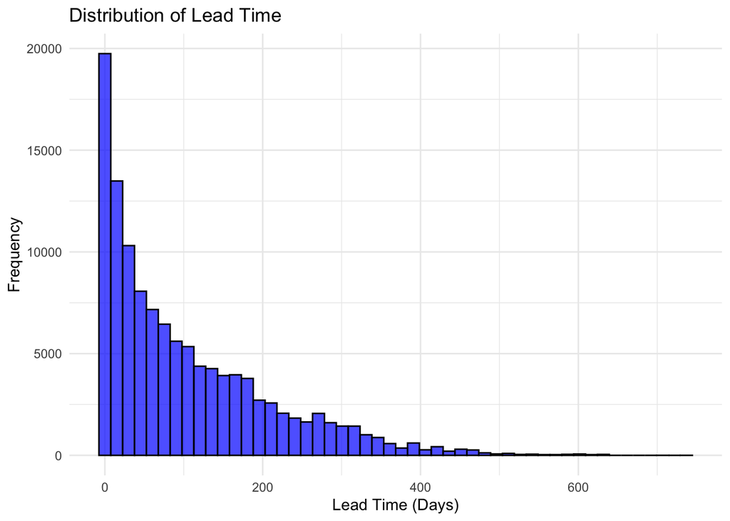

```r
ggplot(df, aes(x = lead_time)) +
  geom_histogram(bins = 50, fill = "blue", color = "black", alpha = 0.7) +
  ggtitle("Distribution of Lead Time") +
  xlab("Lead Time (Days)") +
  ylab("Frequency") +
  theme_minimal()
```

The majority of bookings have short lead times, with a skewed distribution towards longer lead times. A few bookings exhibit exceptionally long lead times, which may impact overall patterns.

2. **Average Daily Rate (ADR) Distribution**

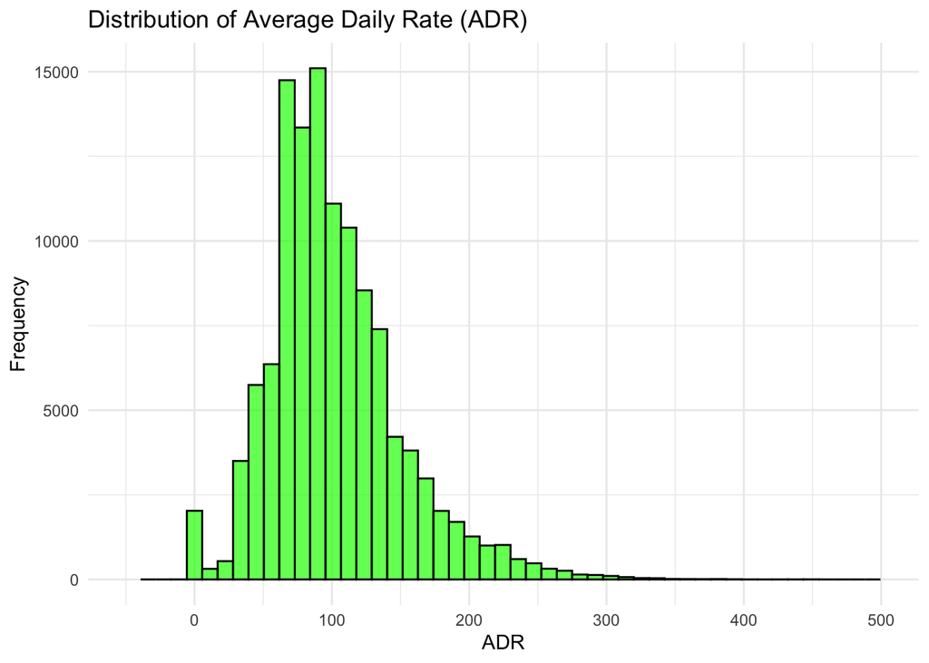

```r
ggplot(df, aes(x = adr)) +
  geom_histogram(bins = 50, fill = "green", color = "black", alpha = 0.7) +
  ggtitle("Distribution of Average Daily Rate (ADR)") +
  xlab("ADR") +
  ylab("Frequency") +
  xlim(-50, 500) +  # Removing extreme outliers
  theme_minimal()
```

The majority of ADR values fall within a reasonable range, but extreme values above 500 indicate possible data inconsistencies

3. **Booking Cancellations**

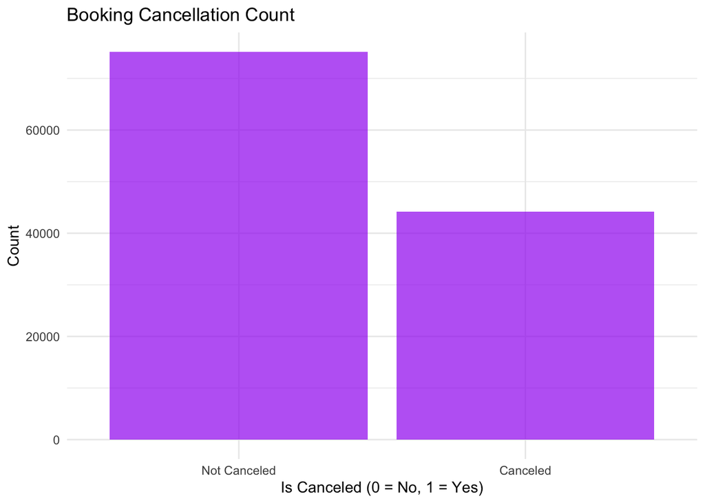

```r
ggplot(df, aes(x = factor(is_canceled))) +
  geom_bar(fill = "purple", alpha = 0.7) +
  ggtitle("Booking Cancellation Count") +
  xlab("Is Canceled (0 = No, 1 = Yes)") +
  ylab("Count") +
  scale_x_discrete(labels = c("Not Canceled", "Canceled")) +
  theme_minimal()
```

A significant 37% of bookings end in cancellation. Further examination is needed to determine influencing factors such as lead time, deposit type, and seasonal trends.

4. **Bookings by Hotel Category**

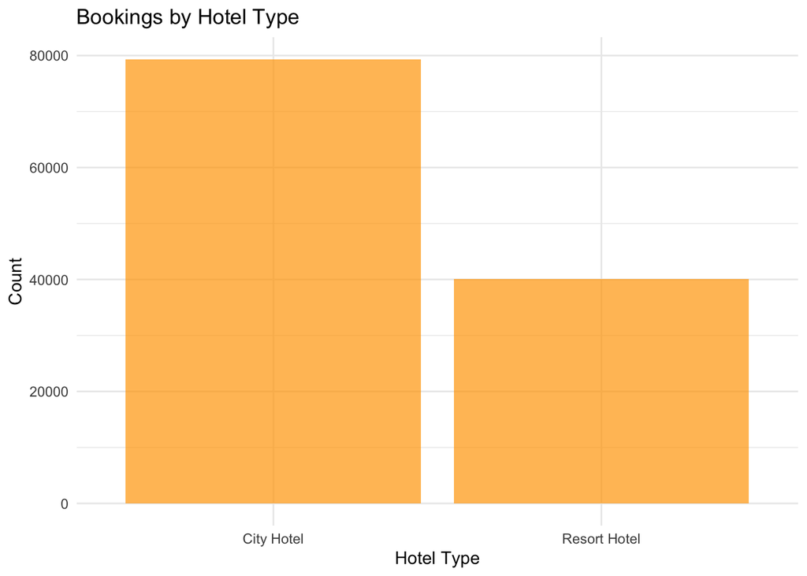

```r
ggplot(df, aes(x = hotel)) +
  geom_bar(fill = "orange", alpha = 0.7) +
  ggtitle("Bookings by Hotel Type") +
  xlab("Hotel Type") +
  ylab("Count") +
  theme_minimal()
```

City Hotels receive a greater number of bookings than Resort Hotels. Differences in ADR and cancellation rates between the two hotel types warrant further investigation.

## Linear Probability Model

A linear probability model (LPM) was estimated using an ordinary least squares (OLS) regression to examine the factors influencing hotel booking cancellations. The dependent variable, is_canceled, is a binary variable indicating whether a booking was canceled (1) or not (0). The independent variables included hotel type (City Hotel vs. Resort Hotel), lead_time (days between booking and arrival), adr (average daily rate), is_holiday (indicator for holiday period), and guests (number of guests).

$$\text{is_cancelled} = \beta_0 + \beta_1 \text{hotel} + \beta_2
\text{lead_time} + \beta_3 \text{adr} + \beta_4 \text{is_holiday} +
\beta_5 \text{guests}$$
``

```r
#Linear Probability Model
model1 = lm(is_canceled ~ hotel + lead_time + adr + is_holiday + guests, data = hotel_bookings)
summary(model1)
```

```
##
## Call:
## lm(formula = is_canceled ~ hotel + lead_time + adr + is_holiday +
##     guests, data = hotel_bookings)
##
## Residuals:
##     Min      1Q  Median      3Q     Max
## -1.8762 -0.3441 -0.2235  0.5154  0.9129
##
## Coefficients:
##                     Estimate Std. Error t value Pr(>|t|)
## (Intercept)        2.092e-01  4.407e-03  47.472  < 2e-16 ***
## hotelResort Hotel -1.129e-01  2.839e-03 -39.773  < 2e-16 ***
## lead_time          1.298e-03  1.254e-05 103.520  < 2e-16 ***
## adr                4.826e-04  2.858e-05  16.888  < 2e-16 ***
## is_holiday        -3.251e-02  1.260e-02  -2.581  0.00984 **
## guests             7.787e-03  1.991e-03   3.910 9.23e-05 ***
## ---
## Signif. codes:  0 '***' 0.001 '**' 0.01 '*' 0.05 '.' 0.1 ' ' 1
##
## Residual standard error: 0.4576 on 119384 degrees of freedom
## Multiple R-squared:  0.1023, Adjusted R-squared:  0.1022
## F-statistic:  2719 on 5 and 119384 DF,  p-value: < 2.2e-16
```

```r
kable(tidy(model1), digits=3, align="c",caption="LPM estimates for the 'Hotel Booking Cancellations", full_width = T)
```

LPM estimates for the ’Hotel Booking Cancellations

| term | estimate | std.error | statistic | p.value |
| --- | --- | --- | --- | --- |
| (Intercept) | 0.209 | 0.004 | 47.472 | 0.00 |
| hotelResort Hotel | -0.113 | 0.003 | -39.773 | 0.00 |
| lead_time | 0.001 | 0.000 | 103.520 | 0.00 |
| adr | 0.000 | 0.000 | 16.888 | 0.00 |
| is_holiday | -0.033 | 0.013 | -2.581 | 0.01 |
| guests | 0.008 | 0.002 | 3.910 | 0.00 |

## Logistic Regression Model

Given the binary nature of the dependent variable, a logistic regression model was also fitted to compare the estimation with the linear probability model. The logistic model follows the equation:

$$\text{logit}(P(\text{is_canceled})) = \beta_0 + \beta_1 \text{hotel} +
\beta_2 \text{lead_time} + \beta_3 \text{adr} + \beta_4
\text{is_holiday} + \beta_5 \text{guests}$$
where logit(P(is_canceled)) is the log-odds of cancellation.

```r
#Logistic Regression Model
model2=glm(is_canceled ~ hotel + lead_time + adr + is_holiday + guests, data = hotel_bookings, family=binomial(link="logit"))
summary(model2)
```

```
##
## Call:
## glm(formula = is_canceled ~ hotel + lead_time + adr + is_holiday +
##     guests, family = binomial(link = "logit"), data = hotel_bookings)
##
## Coefficients:
##                     Estimate Std. Error z value Pr(>|z|)
## (Intercept)       -1.332e+00  2.174e-02 -61.238  < 2e-16 ***
## hotelResort Hotel -5.566e-01  1.394e-02 -39.928  < 2e-16 ***
## lead_time          5.888e-03  6.283e-05  93.710  < 2e-16 ***
## adr                2.690e-03  1.467e-04  18.328  < 2e-16 ***
## is_holiday        -1.594e-01  6.293e-02  -2.532  0.01134 *
## guests             3.093e-02  9.826e-03   3.148  0.00164 **
## ---
## Signif. codes:  0 '***' 0.001 '**' 0.01 '*' 0.05 '.' 0.1 ' ' 1
##
## (Dispersion parameter for binomial family taken to be 1)
##
##     Null deviance: 157398  on 119389  degrees of freedom
## Residual deviance: 144884  on 119384  degrees of freedom
## AIC: 144896
##
## Number of Fisher Scoring iterations: 4
```

```r
kable(tidy(model2), digits=3, align="c",caption="Logistics estimates for the 'Hotel Booking Cancellations", full_width = T)
```

Logistics estimates for the ’Hotel Booking Cancellations

| term | estimate | std.error | statistic | p.value |
| --- | --- | --- | --- | --- |
| (Intercept) | -1.332 | 0.022 | -61.238 | 0.000 |
| hotelResort Hotel | -0.557 | 0.014 | -39.928 | 0.000 |
| lead_time | 0.006 | 0.000 | 93.710 | 0.000 |
| adr | 0.003 | 0.000 | 18.328 | 0.000 |
| is_holiday | -0.159 | 0.063 | -2.532 | 0.011 |
| guests | 0.031 | 0.010 | 3.148 | 0.002 |

## Logistic Regression with only City Hotel

$$\text{logit}(P(\text{is_canceled_cityhotel})) = \beta_1 \text{lead_time}
+ \beta_2 \text{adr} + \beta_3 \text{is_holiday} + \beta_4 \text{guests}$$

```r
cityhotel = subset(hotel_bookings, hotel == "City Hotel")
model3= glm(is_canceled ~ lead_time + adr + is_holiday + guests, data = cityhotel, family=binomial(link="logit"))
summary(model3)
```

```
##
## Call:
## glm(formula = is_canceled ~ lead_time + adr + is_holiday + guests,
##     family = binomial(link = "logit"), data = cityhotel)
##
## Coefficients:
##               Estimate Std. Error z value Pr(>|z|)
## (Intercept) -1.1637515  0.0284890 -40.849  < 2e-16 ***
## lead_time    0.0062654  0.0000767  81.686  < 2e-16 ***
## adr          0.0021079  0.0002199   9.586  < 2e-16 ***
## is_holiday  -0.3677125  0.0788492  -4.663 3.11e-06 ***
## guests      -0.0429592  0.0133711  -3.213  0.00131 **
## ---
## Signif. codes:  0 '***' 0.001 '**' 0.01 '*' 0.05 '.' 0.1 ' ' 1
##
## (Dispersion parameter for binomial family taken to be 1)
##
##     Null deviance: 107793  on 79329  degrees of freedom
## Residual deviance:  99861  on 79325  degrees of freedom
## AIC: 99871
##
## Number of Fisher Scoring iterations: 4
```

```r
kable(tidy(model3), digits=3, align="c",caption="LPM estimates for the 'City Hotel Booking Cancellations with Months", full_width = T)
```

| term | estimate | std.error | statistic | p.value |
| --- | --- | --- | --- | --- |
| (Intercept) | -1.164 | 0.028 | -40.849 | 0.000 |
| lead_time | 0.006 | 0.000 | 81.686 | 0.000 |
| adr | 0.002 | 0.000 | 9.586 | 0.000 |
| is_holiday | -0.368 | 0.079 | -4.663 | 0.000 |
| guests | -0.043 | 0.013 | -3.213 | 0.001 |

```r
stargazer(model2, model3,
  title="Logistic Hotel Bookings Cancellations Models compared",
  header=FALSE,
  type='text', # "html" or "latex" (in index.Rmd)
  report = "vcp",
  omit.table.layout="n",
  star.cutoffs=NA,
  digits=4,
#  single.row=TRUE,
  intercept.bottom=FALSE, #moves the intercept coef to top
  column.labels=c("All Hotels","City Hotels"),
  dep.var.labels.include = FALSE,
  model.numbers = FALSE,
  dep.var.caption="Dependent variable: Hotel Cancellation",
  model.names=FALSE,
  star.char=NULL) #supresses the stars)
```

```
##
## Logistic Hotel Bookings Cancellations Models compared
## =========================================================
##                   Dependent variable: Hotel Cancellation
##                   ---------------------------------------
##                       All Hotels          City Hotels
## ---------------------------------------------------------
## Constant                -1.3316             -1.1638
##                       p = 0.0000          p = 0.0000
##
## hotelResort Hotel       -0.5566
##                       p = 0.0000
##
## lead_time               0.0059              0.0063
##                       p = 0.0000          p = 0.0000
##
## adr                     0.0027              0.0021
##                       p = 0.0000          p = 0.0000
##
## is_holiday              -0.1594             -0.3677
##                       p = 0.0114         p = 0.000004
##
## guests                  0.0309              -0.0430
##                       p = 0.0017          p = 0.0014
##
## ---------------------------------------------------------
## Observations            119,390             79,330
## Log Likelihood       -72,441.9400        -49,930.3300
## Akaike Inf. Crit.    144,895.9000         99,870.6700
## =========================================================
```

## Model Fit and Predictive Performance

### Logistic Regression for All Hotels

```r
# logistic goodness of fit McFadden’s Pseudo R-Square
(RSQ2 <- 1 - model2$deviance/model2$null.deviance)
```

```
## [1] 0.07950769
```

```r
# likelihood ratio test
(lrtest2 <- lrtest(model2))
```

```
## Likelihood ratio test
##
## Model 1: is_canceled ~ hotel + lead_time + adr + is_holiday + guests
## Model 2: is_canceled ~ 1
##   #Df LogLik Df Chisq Pr(>Chisq)
## 1   6 -72442
## 2   1 -78699 -5 12514  < 2.2e-16 ***
## ---
## Signif. codes:  0 '***' 0.001 '**' 0.01 '*' 0.05 '.' 0.1 ' ' 1
```

### Confusion Matrix

To evaluate model accuracy, a confusion matrix was constructed using the predicted probabilities from the logistic regression:

```r
tble <- data.frame(table(true=hotel_bookings$is_canceled,
              predicted=round(fitted(model2))))
kable(tble, align='c', caption="Logit Confusion Matrix")
```

Logit Confusion Matrix

| true | predicted | Freq |
| --- | --- | --- |
| 0 | 0 | 66208 |
| 1 | 0 | 30642 |
| 0 | 1 | 8958 |
| 1 | 1 | 13582 |

### Accuracy of the model:

```r
total_obs = nrow(hotel_bookings)
correct_pred = 66208 +13582
accuracy = correct_pred/total_obs
accuracy
```

```
## [1] 0.6683139
```

### Specificity and Sensitivity:

```r
# Calculate sensitivity and specificity
# Create confusion matrix

confusion_matrix <- xtabs(Freq ~ true + predicted, tble)

# Rename rows and columns for clarity
rownames(confusion_matrix) <- c("Actual 0", "Actual 1")
colnames(confusion_matrix) <- c("Predicted 0", "Predicted 1")

# View the confusion matrix
kable(confusion_matrix, align='c', caption="Logit Confusion Matrix")
```

Logit Confusion Matrix

|  | Predicted 0 | Predicted 1 |
| --- | --- | --- |
| Actual 0 | 66208 | 8958 |
| Actual 1 | 30642 | 13582 |

```r
sensitivity <- confusion_matrix[2, 2] / (confusion_matrix[2, 2] + confusion_matrix[2, 1])

specificity <- confusion_matrix[1, 1] / (confusion_matrix[1, 1] + confusion_matrix[1, 2])

results_table <- data.frame(Metric = c("Sensitivity", "Specificity"), Value = c(sensitivity, specificity))

kable(results_table, align='c', caption="Logit Confusion Matrix")
```

Logit Confusion Matrix

| Metric | Value |
| --- | --- |
| Sensitivity | 0.3071183 |
| Specificity | 0.8808238 |

- Accuracy: 66.83% of the observations were correctly classified.
- Specificity (True Negative Rate): The model correctly identified 88.1% of non-cancellations.
- Sensitivity (True Positive Rate): The model correctly identified 30.7% of cancellations.

While the specificity is high, indicating that the model is good at detecting when a booking will not be canceled, the relatively lower sensitivity suggests room for improvement in predicting actual cancellations.

### Logistic Regression for City Hotels

```r
# logistic goodness of fit McFadden’s Pseudo R-Square
(RSQ2 <- 1 - model3$deviance/model3$null.deviance)
```

```
## [1] 0.07358746
```

```r
# likelihood ratio test
(lrtest3 <- lrtest(model3))
```

```
## Likelihood ratio test
##
## Model 1: is_canceled ~ lead_time + adr + is_holiday + guests
## Model 2: is_canceled ~ 1
##   #Df LogLik Df  Chisq Pr(>Chisq)
## 1   5 -49930
## 2   1 -53896 -4 7932.2  < 2.2e-16 ***
## ---
## Signif. codes:  0 '***' 0.001 '**' 0.01 '*' 0.05 '.' 0.1 ' ' 1
```

### Confusion Matrix

To evaluate model accuracy, a confusion matrix was constructed using the predicted probabilities from the logistic regression:

```r
tble <- data.frame(table(true=cityhotel$is_canceled,
              predicted=round(fitted(model3))))
kable(tble, align='c', caption="Logit Confusion Matrix")
```

Logit Confusion Matrix

| true | predicted | Freq |
| --- | --- | --- |
| 0 | 0 | 38723 |
| 1 | 0 | 20390 |
| 0 | 1 | 7505 |
| 1 | 1 | 12712 |

### Accuracy of the model:

```r
total_obs = nrow(cityhotel)
correct_pred = 38723 +12712
accuracy = correct_pred/total_obs
accuracy
```

```
## [1] 0.6483676
```

### Specificity and Sensitivity:

```r
# Calculate sensitivity and specificity
# Create confusion matrix

confusion_matrix <- xtabs(Freq ~ true + predicted, tble)

# Rename rows and columns for clarity
rownames(confusion_matrix) <- c("Actual 0", "Actual 1")
colnames(confusion_matrix) <- c("Predicted 0", "Predicted 1")

# View the confusion matrix
kable(confusion_matrix, align='c', caption="Logit Confusion Matrix")
```

Logit Confusion Matrix

|  | Predicted 0 | Predicted 1 |
| --- | --- | --- |
| Actual 0 | 38723 | 7505 |
| Actual 1 | 20390 | 12712 |

```r
sensitivity <- confusion_matrix[2, 2] / (confusion_matrix[2, 2] + confusion_matrix[2, 1])

specificity <- confusion_matrix[1, 1] / (confusion_matrix[1, 1] + confusion_matrix[1, 2])

results_table <- data.frame(Metric = c("Sensitivity", "Specificity"), Value = c(sensitivity, specificity))

kable(results_table, align='c', caption="Logit Confusion Matrix")
```

Logit Confusion Matrix

| Metric | Value |
| --- | --- |
| Sensitivity | 0.3840251 |
| Specificity | 0.8376525 |

- Accuracy: 64.83% of the observations were correctly classified.
- Specificity (True Negative Rate): The model correctly identified 83.76% of non-cancellations.
- Sensitivity (True Positive Rate): The model correctly identified 38.4% of cancellations.

While the specificity is high, indicating that the model is good at detecting when a booking will not be canceled, the relatively lower sensitivity suggests room for improvement in predicting actual cancellations.

# Results

### Linear Probability Model

The LPM results indicate that lead_time is a strong predictor of cancellations (p < 0.001), suggesting that bookings made further in advance are more likely to be canceled. The coefficient for hotel type is negative, implying that bookings at Resort Hotels are less likely to be canceled compared to City Hotels. The adr variable has a positive coefficient, suggesting that higher average daily rates are associated with a slightly increased likelihood of cancellation. The is_holiday variable has a small but significant negative effect, indicating that bookings during holidays are slightly less likely to be canceled. The number of guests is positively associated with cancellation likelihood. The model has an adjusted R^2 value of 0.1022, indicating that approximately 10.2% of the variation in cancellations is explained by the model.

### Logistic Regression Model of City Hotels

# Discussion and Conclusion

This analysis demonstrates that lead_time is the strongest predictor of hotel booking cancellations. The logistic regression results indicate that for each additional day in lead time, the odds of cancellation increase by 1.006 times (exp(0.0059) ≈ 1.006), holding everything else constant.

The Logistic Regression model outperforms the Linear Probability Model (LPM) since the dependent variable is binary. While LPM provides an interpretable way to assess relationships, it does not constrain predicted probabilities between 0 and 1, making it unsuitable for classification. Additionally, heteroskedasticity is a common issue in LPMs, leading to inefficient estimates.

Although the logistic regression model captures statistically significant predictors, the McFadden’s Pseudo R² (0.0795) in the first logistic model suggests that additional factors influence cancellations beyond those included in the model. Incorporating variables related to customer behavior, economic conditions, and competitor pricing could improve predictive accuracy.

While the model achieves high specificity (88.1%), meaning it effectively identifies bookings that will not be canceled, it struggles with low sensitivity (30.7%), indicating that it fails to detect many actual cancellations. This misclassification could lead to revenue loss, as hotels may not properly manage inventory to account for expected cancellations. Adjusting the classification threshold or incorporating additional predictive features may improve sensitivity.

# Recommendations

To further refine hotel cancellation predictions, we propose:

1. **Enhancing Model Complexity:** Incorporate interaction effects (e.g., between lead_time and adr) to determine if pricing influences cancellations differently based on booking time.
2. **Exploring Non-Linear Models:** Decision Trees, Random Forests, and Gradient Boosting models can capture complex interactions between features, potentially improving sensitivity.These models also handle categorical variables more effectively, making them suitable for analyzing differences in cancellation patterns between City and Resort Hotels.
3. **Practical Business Strategies Based on Findings:** Require deposits for long lead-time bookings to reduce speculative reservations. Offer non-refundable discounts to encourage commitment from customers. Send automated booking confirmation reminders to customers with long lead times, reducing last-minute cancellations.

By implementing these strategies and refining the predictive models, hotels can improve cancellation forecasting, optimize revenue management, and reduce financial losses associated with unanticipated cancellations.

# Reference

1. Booking Prediction Models for Peer-to-peer Accommodation Listings using Logistics Regression, Decision Tree, K- Nearest Neighbour, and Random Forest Classifiers by Mochammad Agus Afrianto
2. Hotel booking demand datasets by NunoAntonio, AnadeAlmeida, LuisNunes
3. Kaggle Dataset Hotel booking demand by Jesse Mostipak
4. Optimizing hotel Booking Prediction: A Comparative Study of Five Machine Learning Algorithms by Syed Osama Ali Shah